# Week 7

Nonlinear programming, Ch 13

Gareth Green

# Nonlinear programming basics - concave vs convex

- Concave and convex functions (of one variable)
  - Concave $126x_1 - 9x_1^2$
  - Convex $300 - 126x_1 + 9x_1^2$
- Take the first and second derivative of each
  - Do they fit the assumptions?

# Nonlinear programming basics - concave vs convex

- Concave and convex functions (of one variable)
  - Concave $126x_1 - 9x_1^2$
  - Convex $300 - 126x_1 + 9x_1^2$
- Take the first and second derivative of each
  - Do they fit the assumptions?

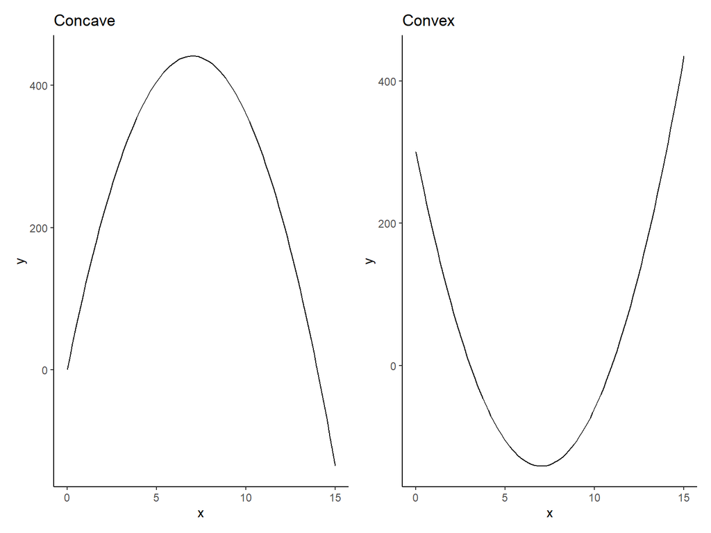

```r
# Concave function
cave <- ggplot(data = data.frame(x = 0), mapping = aes(x = x)) +
  stat_function(fun = (function (x) 126*x - 9*x^2)) +
  xlim(0, 15) +
  labs(title = "Concave") +
  theme_classic()

# Convex function
vex <- ggplot(data = data.frame(x = 0), mapping = aes(x = x)) +
  stat_function(fun = (function (x) 300 - 126*x + 9*x^2)) +
  xlim(0, 15) +
  labs(title = "Convex") +
  theme_classic()
```

# Nonlinear programming basics - two variables

- Concave function of two variables
  - $126x_1 - 9x_1^2 + 180x_2 - 12x_2^2$
  - does this function meet concavity assumptions?
    - take the first and second derivative
- How would you find the optimal values of $x_1$ and $x_2$?
  - there is no constaint so you would not need to set up a Lagrangian

# Nonlinear programming basics - two variables

- Concave function of two variables
  - $126x_1 - 9x_1^2 + 180x_2 - 12x_2^2$
  - does this function meet concavity assumptions?
    - take the first and second derivative
- How would you find the optimal values of $x_1$ and $x_2$?
  - there is no constaint so you would not need to set up a Lagrangian

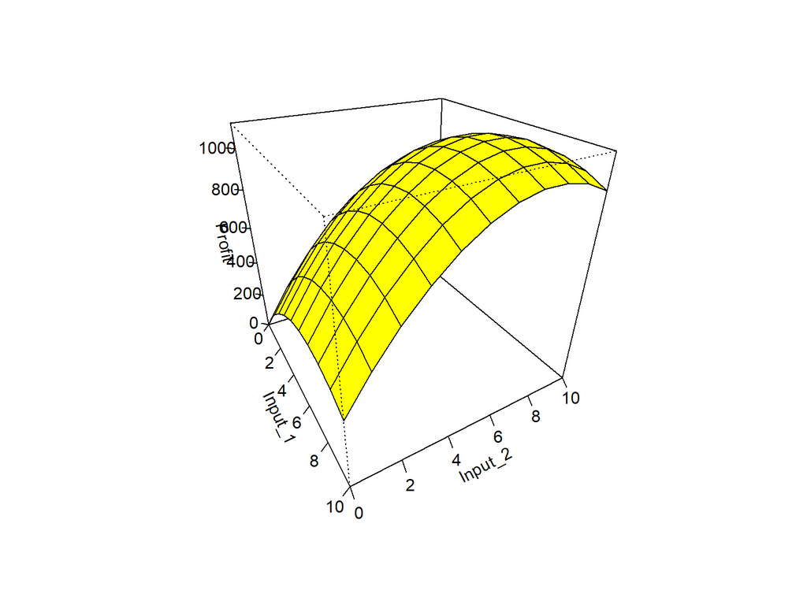

```r
# Make the function
f1 <- function(x1, x2) 126*x1 - 9*x1^2 + 180*x2 - 12*x2^2

# Create the data
Input_1 <- seq(0, 10, by = 1)
Input_2 <- seq(0, 10, by = 1)
Profit <- outer(Input_1, Input_2, f1)

# Graph the data using persp(), a base graphics function
persp(x = Input_1, y = Input_2, z = Profit, phi = 30, theta = 60,
                 col = "yellow", ticktype = "detailed")
```

# Nonlinear programming basics - convex set

- Convex set (of one variable)
  - Where is the maximum?

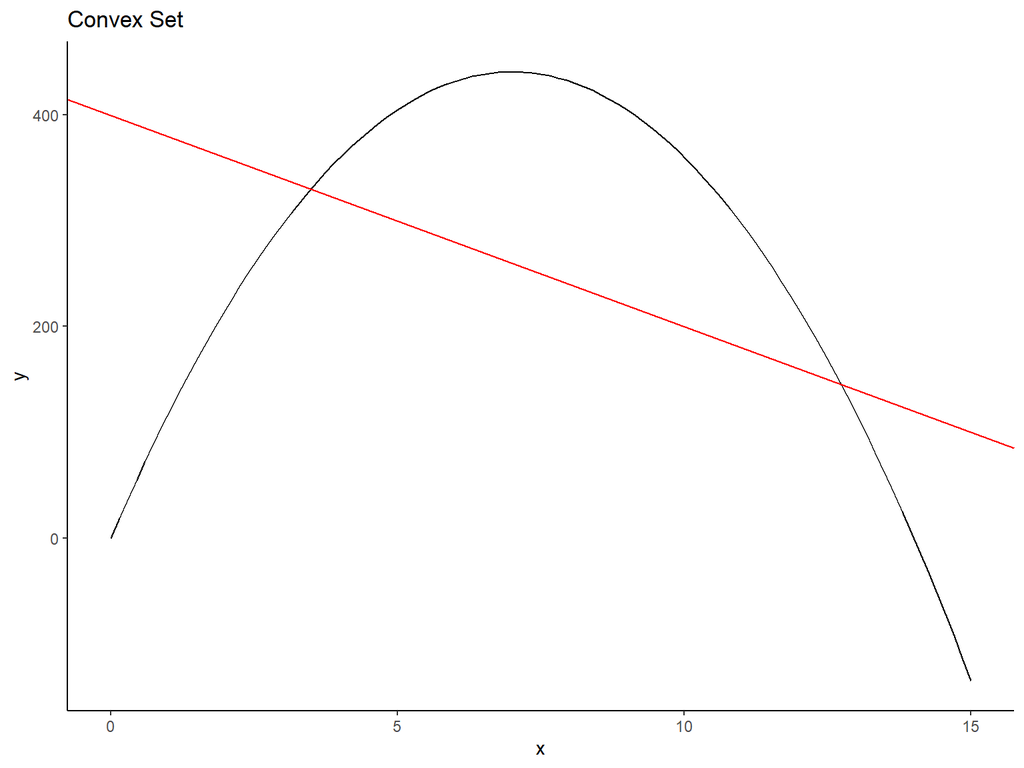

```r
# Convex set
con_set <- ggplot(data = data.frame(x = 0), mapping = aes(x = x)) +
  stat_function(fun = (function (x) 126*x - 9*x^2)) +
  geom_abline(intercept = 400, slope = -20, color = "red") +
  xlim(0, 15) +
  labs(title = "Convex Set") +
  theme_classic()
```

# Nonlinear programming basics - non-convex set

- The black line is not concave or convex over its whole range
  - Not a convex set
  - Not work for either min or max
  - Unless over limited range

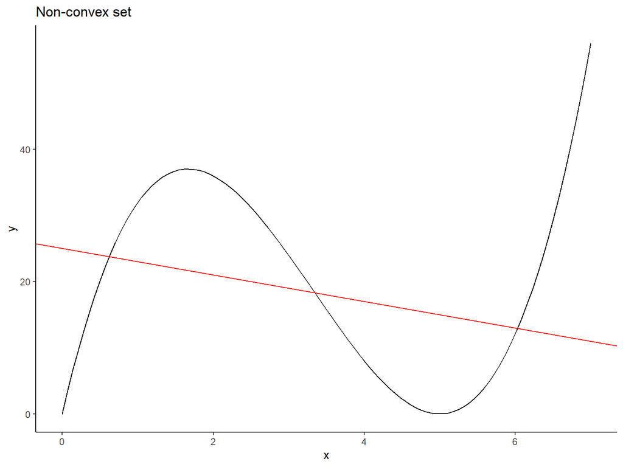

```r
# Convex set
non_con <- ggplot(data = data.frame(x = 0), mapping = aes(x = x)) +
  stat_function(fun = (function (x) f2 <- 50*x - 20*x^2 + 2*x^3)) +
  geom_abline(intercept = 25, slope = -2, color = "red") +
  xlim(0, 7) +
  labs(title = "Non-convex set") +
  theme_classic()
```

# Constrained optimization in R

- There are a number of programs you can use for different types of optimization
  - See **CRAN Task View: Optimization and Mathematical Programming**

https://cran.r-project.org/web/views/Optimization.html

- The primary package we will use is **nloptr**
  - **nloptr** is an R interface to **NLopt**
  - NLopt is an open source library of optimization algorithms

[https://nlopt.readthedocs.io/en/latest/NLopt_Introduction/](https://cran.r-project.org/web/views/Optimization.html)

- nloptr does not have a maximization setting
  - All problems have to be set up as a minimization
  - Remember, to convert a minimum to be a maximum just multiplying the objective function by -1
- It is necessary to select an optimization algorithm and starting values
- Nonlinear optimization is very technical
  - Many choices of optimization methods
  - Really kind of an art, so begin by trial and error
- **Syntax can be confusing**
  - We will work through some examples

# Constrained optimization in R

- Recall the problem we solved by hand from the notes

$$max_{x_i} \; \pi = \; 126x_1 \; - \; 9x_1^2 \; + \; 180x_2 \; - \; 12x_2^2 \\
subject \; to: \; 3x_1 \; + \; 2x_2 \; \le \; 16\;\;\;\;\;\;\;\;\;\;\;\;\;\;\;\;\;\;\; \\
0 \; \le \; x_1, \; x_2 \;\;\;\;\;\;\;\;\;\\$$

- Let’s set this up and solve in R
- But first make sure it meets maximization criteria by checking the first and section derivatives of the objective function:
  - First w.r.t. $x_1$: $\partial \pi / \partial x_1 = 126 - 18x_1 \ge 0$ and
  - Second w.r.t. $x_1$: $\partial^2 \pi / \partial x_1^2 = -18 \le 0$
  - First w.r.t. $x_2$: $\partial \pi / \partial x_2 = 180 - 24x_2 \ge 0$ and
  - Second w.r.t. $x_2$: $\partial^2 \pi / \partial x_2^2 = -24 \le 0$
- For *max* a *quasi-convex* set of constraints
  - quasi-convex means either convex or linear
  - the constraint is linear
- So we are good to go

# Setting up problems in nloptr

- **nloptr** is set up to to accept R functions
  - we will set up **functions** for the objective and the constraints
  - it is a maximum so need to multiply by $-1$
- Recall defining f() as objective function and g() as constraint

```r
# The objective function
eval_f <- function(x, a, b, c){
  return( -(126*x[1] - 9*x[1]^2 + 180*x[2] - 12*x[2]^2 )) # This indicates x will be a vector with two elements
  }

# Constraint functions
# This one function creates all constraints
eval_g <- function(x, a, b, c) {
  return( a*x[1] + b*x[2] - c )    # This will create as many constraints as there are elements
  }                                # But a, b and c must all be the same length

# Define parameters of constraints, only one constraint so only 1 entry for each
a <- c( 3 ) # Coefficients for column 1
b <- c( 2 ) # Coefficients for column 2
c <- c( 16 ) # Coefficients for rhs constaints
```

# Solve the model, set the options

```r
# Set up model calling nloptr function and set values
nlp <- nloptr( x0 = c(0, 0),       # Set the inital values of x
                                    # Should try range of initial values to check global solution
                eval_f = eval_f,   # Call the obj fn
                lb = c(  0,  0),    # Set lower and upper bounds on the decision variables
                ub = c(Inf, Inf),
                eval_g_ineq = eval_g, # Call the inequality constraints, diff call for equality cons
                opts = list("algorithm"="NLOPT_LN_COBYLA", # Set the search algorithm, use NLOPT_LN_COBYLA
                            "xtol_rel" = 0.001), # Set search tolerance
                a = a,  # Call constraint parmeter values
                b = b,
                c = c)
```

# Solve and check solution makes sense

- Let’s look at the results relative to the model
  - The first bit is just a repeat of the model call and solution status
  - There are three items I am interested in
    1. Number of itterations - how many search steps to find the solution
    2. The objective function value
    3. The decision variable values
- Why aren’t the values whole numbers like when we sovled by hand?

```r
# Print model output
print(nlp)
```

```
##
## Call:
## nloptr(x0 = c(0, 0), eval_f = eval_f, lb = c(0, 0), ub = c(Inf,
##     Inf), eval_g_ineq = eval_g, opts = list(algorithm = "NLOPT_LN_COBYLA",
##     xtol_rel = 0.001), a = a, b = b, c = c)
##
##
## Minimization using NLopt version 2.4.2
##
## NLopt solver status: 4 ( NLOPT_XTOL_REACHED: Optimization stopped because
## xtol_rel or xtol_abs (above) was reached. )
##
## Number of Iterations....: 49
## Termination conditions:  xtol_rel: 0.001
## Number of inequality constraints:  1
## Number of equality constraints:    0
## Optimal value of objective function:  -815.999998719048
## Optimal value of controls: 1.999811 5.000283
```

# What about the dual value??

- Unfortunately nloptr does not provide dual values
  - further, the sensitivity ranges are not applicable
  - generally the duals, variables and object function will change if a binding constraint is changed
  - this is because the non-linear functions we are working with are smooth
    - incremental change is possible
- To find the dual of a binding constraint you can add 1 to the constraint
  - so the revised constraint in the above problem is $3x_1 + 2x_2 \le 17$
  - then rerun the model

```r
# Set up model calling nloptr function and set values
nlp_d <- nloptr( x0 = c(0, 0),       # Set the inital values of x
                                    # Should try range of initial values to check global solution
                eval_f = eval_f,   # Call the obj fn
                lb = c(  0,  0),    # Set lower and upper bounds on the decision variables
                ub = c(Inf, Inf),
                eval_g_ineq = eval_g, # Call the inequality constraints, diff call for equality cons
                opts = list("algorithm"="NLOPT_LN_COBYLA", # Set the search algorithm, use NLOPT_LN_COBYLA
                            "xtol_rel" = 0.001), # Set search tolerance
                a = a,  # Call constraint parmeter values
                b = b,
                c = 17)
```

- The original solution was $x_1$ = 2, $x_2$ = 5, and $\pi$ = $816
- The new solution is $x_1$ = 2.25, $x_2$ = 5.12, and $\pi$ = $845.25
- So the dual value is $29.25

# Solve question 13.6-10

- Does the set of equations fit the conditions of a minimization?
  - Take the first and second derivative of each
  - For *min* need a convex objective fundtion
    - positive second derivative
  - For *min* a *quasi-concave* set of constraints
    - quasi-concave means either concave or linear

$$min_{x_i} \;\;\; Z = 2x_1^2 \; + \; x_2^2 \\
s.t.\;\;\;\;\;\;\;\;\;\;\;\;\;\;\;\;\;\;\;\;\;\;\;\; \\
\;\;\;\; x_1 + x_2 \; \ge \; 10 \\
\;\;\;\;\;\;\; x_1 - x_2 \; \ge \;-10 \\
\;\;0 \; \le \; x_1, \; x_2 \\$$

- The first and section derivatives of the objective function are:
  - First w.r.t. $x_1$: $\partial Z / \partial x_1 = 4x_1 \ge 0$ and
  - Second w.r.t. $x_1$: $\partial^2 Z / \partial x_1^2 = 4 \ge 0$
  - First w.r.t. $x_2$: $\partial Z / \partial x_2 = 2x_2 \ge 0$ and
  - Second w.r.t. $x_2$: $\partial^2 Z / \partial x_2^2 = 2 \ge 0$
- The constraints are linear so have a convex set
  - that is, the functions meet the conditions for a minimization

# Set up the model in nloptr

- **nloptr** is set up to to accept R functions
  - We will set up functions for the objective and the constraints

```r
# The objective function
eval_f1 <- function(x, a, b, c){
  return(2*x[1]^2 + x[2]^2 )       # This indicates x will be a vector with two elements
  }

# Constraint functions
# This one function creates all constraints
eval_g1 <- function(x, a, b, c) {
  return( a*x[1] + b*x[2] - c )    # This will create as many constraints as there are elements
  }                                # But a, b and c must all be the same length

# define parameters of constraints
a <- c( 1,  1 ) # Coefficients for column 1
b <- c( 1, -1 ) # Coefficients for column 2
c <- c( 10,-10) # Coefficients for rhs constaints
```

# Set the options and solve

- Calling the nloptr() function with options set solves the model

```r
# Set up model calling nloptr function and set values
nlp1 <- nloptr( x0 = c(0, 0),       # Set the inital values of x
                                    # Should try range of initial values to check global solution
                eval_f = eval_f1,   # Call the obj fn
                lb = c(  0,  0),  # Set lower and upper bounds on the decision variables
                ub = c(Inf, Inf),
                eval_g_ineq = eval_g1, # Call the inequality constraints, diff call for equality cons
                opts = list("algorithm"="NLOPT_LN_COBYLA", # Set the search algorithm, use NLOPT_LN_COBYLA
                            "xtol_rel" = 0.001), # Set search tolerance
                a = a,            # Call constraint parmeter values
                b = b,
                c = c)
```

# Solve and check solution makes sense

- Let’s look at the results relative to the model

```r
# Print model output
print(nlp1)
```

```
##
## Call:
## nloptr(x0 = c(0, 0), eval_f = eval_f1, lb = c(0, 0), ub = c(Inf,
##     Inf), eval_g_ineq = eval_g1, opts = list(algorithm = "NLOPT_LN_COBYLA",
##     xtol_rel = 0.001), a = a, b = b, c = c)
##
##
## Minimization using NLopt version 2.4.2
##
## NLopt solver status: 4 ( NLOPT_XTOL_REACHED: Optimization stopped because
## xtol_rel or xtol_abs (above) was reached. )
##
## Number of Iterations....: 38
## Termination conditions:  xtol_rel: 0.001
## Number of inequality constraints:  2
## Number of equality constraints:    0
## Optimal value of objective function:  100
## Optimal value of controls: 0 10
```

$$min_{x_i} \;\;\;\;\; 2x_1^2 \; + \; x_2^2 \\
subject \; to: \;\;\;\;\;\;\;\;\;\;\;\;\;\;\;\;\;\;\; \\
\;\;\;\; x_1 + x_2 \; \ge \; 10 \\
\;\;\;\;\;\;\; x_1 - x_2 \; \ge \;-10 \\
\;\;0 \; \le \; x_1, \; x_2 \\$$

# How was that problem solved??

- We know in R the solution was found numerically
  - Could you solve with Lagrangian method??
    - yes, but you would need to use the Khun-Tucker conditions
- I will add one more option to illustrate the numerical process
  - **print_level = 3** shows the itterations of the search algorithm

```r
# Set up model calling nloptr function and set values
nlp1 <- nloptr( x0 = c(0, 0),       # Set the inital values of x
                                    # Should try range of initial values to check global solution
                eval_f = eval_f1,   # Call the obj fn
                lb = c(  0,  0),  # Set lower and upper bounds on the decision variables
                ub = c(Inf, Inf),
                eval_g_ineq = eval_g1, # Call the inequality constraints, diff call for equality cons
                opts = list("algorithm"="NLOPT_LN_COBYLA", # Set the search algorithm, use NLOPT_LN_COBYLA
                            "xtol_rel" = 0.001, # Set search tolerance
                            print_level = 3),
                a = a,            # Call constraint parmeter values
                b = b,
                c = c)
```

```
## iteration: 1
##  x = ( 0.000000, 0.000000 )
##  f(x) = 0.000000
##  g(x) = ( -10.000000, 10.000000 )
## iteration: 2
##  x = ( 1.000000, 0.000000 )
##  f(x) = 2.000000
##  g(x) = ( -9.000000, 11.000000 )
## iteration: 3
##  x = ( 0.000000, 1.000000 )
##  f(x) = 1.000000
##  g(x) = ( -9.000000, 9.000000 )
## iteration: 4
##  x = ( 0.000000, 1.707107 )
##  f(x) = 2.914214
##  g(x) = ( -8.292893, 8.292893 )
## iteration: 5
##  x = ( 0.000000, 1.353553 )
##  f(x) = 1.832107
##  g(x) = ( -8.646447, 8.646447 )
## iteration: 6
##  x = ( 0.136545, 1.000000 )
##  f(x) = 1.037289
##  g(x) = ( -8.863455, 9.136545 )
## iteration: 7
##  x = ( 0.000000, 1.707107 )
##  f(x) = 2.914214
##  g(x) = ( -8.292893, 8.292893 )
## iteration: 8
##  x = ( 0.000000, 2.060660 )
##  f(x) = 4.246320
##  g(x) = ( -7.939340, 7.939340 )
## iteration: 9
##  x = ( 0.000000, 2.414214 )
##  f(x) = 5.828427
##  g(x) = ( -7.585786, 7.585786 )
## iteration: 10
##  x = ( 0.000000, 2.767767 )
##  f(x) = 7.660534
##  g(x) = ( -7.232233, 7.232233 )
```

[output cut: 97 more lines]

```
##  x = ( 0.003196, 10.000000 )
##  f(x) = 100.000020
##  g(x) = ( 0.003196, 0.003196 )
## iteration: 36
##  x = ( 0.000000, 9.999642 )
##  f(x) = 99.992850
##  g(x) = ( -0.000358, 0.000358 )
## iteration: 37
##  x = ( 0.000000, 9.999379 )
##  f(x) = 99.987584
##  g(x) = ( -0.000621, 0.000621 )
## iteration: 38
##  x = ( 0.000415, 10.000000 )
##  f(x) = 100.000000
##  g(x) = ( 0.000415, 0.000415 )
```

# Examining a more complex objective function

$$max_{x_i} \; \pi = 32x_1 - x_1^4 + 50x_2 - 20x_2^2 + 2x_2^3 \\
subject \; to: \;\;\;\;\;\;\;\;\;\;\;\;\;\;\;\;\;\;\;\;\;\;\;\;\;\;\;\;\;\;\;\;\;\;\;\;\;\;\;\;\;\;\;\;\;\; \\
3x_1 + 2x_2 \; \le \; 12 \\
2x_1 + 5x_2 \; \le \; 30 \\
0 \; \le \; x_1, x_2$$

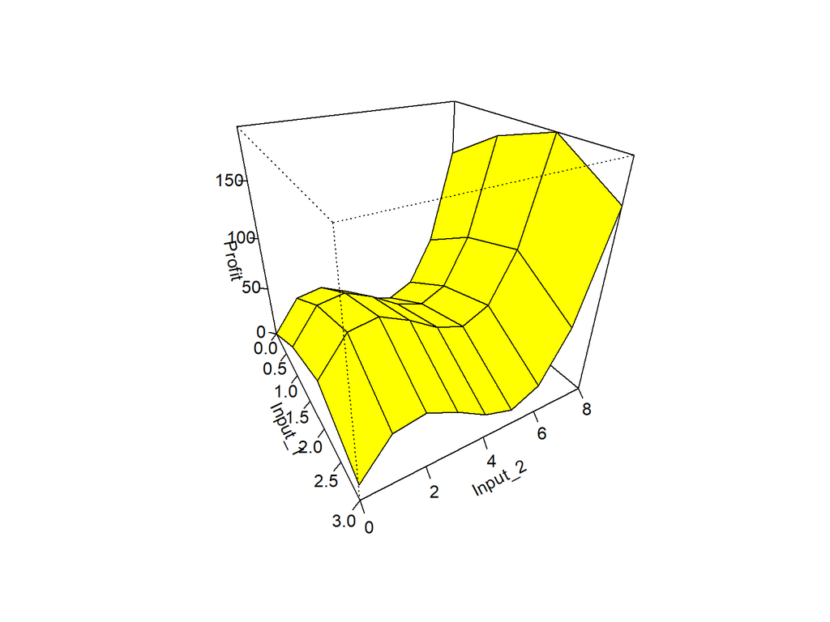

# Find the range of concavity

- Lets check the $1^{st}$ and $2^{nd}$ order conditions for $x_1$ and $x_2$
  - f.o.c. $x_1$: $\partial \pi / \partial x_1 = 32 - 4x_1^3$
  - s.o.c. $x_1$: $\partial^2\pi \partial x_1^2 = - 12x_1^2 \le 0$ for all $x_1$
  - f.o.c. $x_2$: $\partial \pi / \partial x_2 = 50 - 40x_2 + 6x_2^2$
  - s.o.c. $x_2$: $\partial^2\pi \partial x_2^2 = - 40 + 12x_2 \le 0$ for a range of $x_2$$
- It appears the objective function is only concave in $x_2$ over a limited range–how find that range?
  - set equal to 0 and solve for $x_2$
  - $12x_2 = 40$
  - $x_2 = 40/12 = 3.333$
  - so the objective function is concave over the range of $x_1$ and $0 \le x_2 \le 3.333$
  - if we use initial conditions with $x_2 \le 3.333$ we will get a local max
  - regardless, not have to try different values to find global max

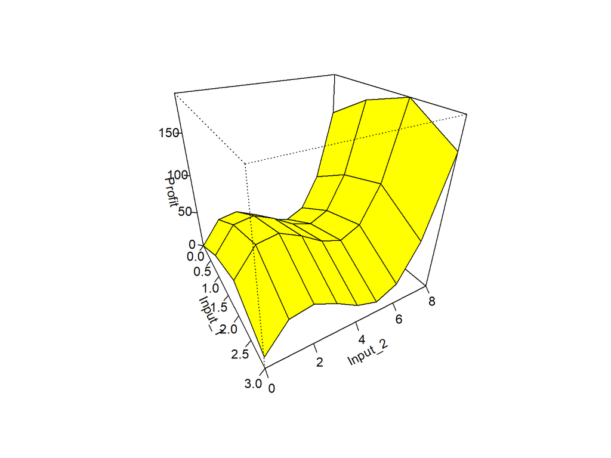

# Set up and run the model in nloptr

- First lets run the model with initial starting point (0, 0)

```r
# This is a maximum so multiply the obj fn by -1
eval_f2 <- function(x, a, b, c){
  return( -(32*x[1] - x[1]^4 + 50*x[2] - 20*x[2]^2 + 2*x[2]^3) )
  }

# constraint function
eval_g2 <- function(x, a, b, c) { return( a*x[1] + b*x[2] - c )
  }

# define parameters
a <- c(  3,  2)
b <- c(  2,  5)
c <- c( 12, 30)

# Solve using algorithm NLOPT_LN_COBYLA
nlp2 <- nloptr( x0 = c(0, 0),
                eval_f=eval_f2,
                lb = c(  0,  0),
                ub = c(Inf, Inf),
                eval_g_ineq = eval_g2,
                opts = list("algorithm"="NLOPT_LN_COBYLA"),
                a = a,
                b = b,
                c = c )
print(nlp2)
```

```
##
## Call:
## nloptr(x0 = c(0, 0), eval_f = eval_f2, lb = c(0, 0), ub = c(Inf,
##     Inf), eval_g_ineq = eval_g2, opts = list(algorithm = "NLOPT_LN_COBYLA"),
##     a = a, b = b, c = c)
##
##
## Minimization using NLopt version 2.4.2
##
## NLopt solver status: 4 ( NLOPT_XTOL_REACHED: Optimization stopped because
## xtol_rel or xtol_abs (above) was reached. )
##
## Number of Iterations....: 37
## Termination conditions:  relative x-tolerance = 1e-04 (DEFAULT)
## Number of inequality constraints:  2
## Number of equality constraints:    0
## Optimal value of objective function:  -85.0370369236058
## Optimal value of controls: 2.000008 1.666773
```

- So optimal solution is $x_1$ = 2, $x_2$ = 1.67, and $\pi$ = $85.04

# Set up and run the model in nloptr

- Second lets run the model with initial starting point (0, 5)
- Note, we do not need to redefine the model, just the initial condition

```r
# Solve using algorithm NLOPT_LN_COBYLA
nlp2 <- nloptr( x0 = c(0, 5),
                eval_f=eval_f2,
                lb = c(  0,  0),
                ub = c(Inf, Inf),
                eval_g_ineq = eval_g2,
                opts = list("algorithm"="NLOPT_LN_COBYLA"),
                a = a,
                b = b,
                c = c )
print(nlp2)
```

```
##
## Call:
## nloptr(x0 = c(0, 5), eval_f = eval_f2, lb = c(0, 0), ub = c(Inf,
##     Inf), eval_g_ineq = eval_g2, opts = list(algorithm = "NLOPT_LN_COBYLA"),
##     a = a, b = b, c = c)
##
##
## Minimization using NLopt version 2.4.2
##
## NLopt solver status: 4 ( NLOPT_XTOL_REACHED: Optimization stopped because
## xtol_rel or xtol_abs (above) was reached. )
##
## Number of Iterations....: 14
## Termination conditions:  relative x-tolerance = 1e-04 (DEFAULT)
## Number of inequality constraints:  2
## Number of equality constraints:    0
## Optimal value of objective function:  -12
## Optimal value of controls: 1.63064e-16 6
```

# Nonlinear objective and constraints

- Another example, but demonstrate benefit of gradients and Jacobians
  - the constraints are now nonlinear

$$max_{x_i} \; \pi = 32x_1 - x_1^4 + 50x_2 - 20x_2^2 + 2x_2^3 \\
subject \; to: \;\;\;\;\;\;\;\;\;\;\;\;\;\;\;\;\;\;\;\;\;\;\;\;\;\;\;\;\;\;\;\;\;\;\;\;\;\;\;\;\;\;\;\;\;\; \\
3x_1^2 + 2x_2 \; \le \; 12 \\
2x_1 + 5x_2^2 \; \le \; 30 \\
0 \; \le \; x_1, x_2$$

# Nonlinear constraints

- Constraint functions need to be specified individually due to exponents
  - Can you think of way to specify constraints

```r
# Constraints have different exponents
eval_g2 <- function(x, a, b, c) { return( c(a[1]*x[1]^2 + b[1]*x[2]   - c[1],
                                            a[2]*x[1]   + b[2]*x[2]^2 - c[2]) )
  }
```

# Solve the model, set the options

```r
# Solve using algorithm NLOPT_LN_COBYLA
nlp2 <- nloptr( x0 = c(0, 0),
                eval_f = eval_f2,
                lb = c(  0,  0),
                ub = c(Inf, Inf),
                eval_g_ineq = eval_g2,
                opts = list("algorithm"="NLOPT_LN_COBYLA",
                            "xtol_rel" = 0.001),
                a = a,
                b = b,
                c = c )
```

```
##
## Call:
## nloptr(x0 = c(0, 0), eval_f = eval_f2, lb = c(0, 0), ub = c(Inf,
##     Inf), eval_g_ineq = eval_g2, opts = list(algorithm = "NLOPT_LN_COBYLA",
##     xtol_rel = 0.001), a = a, b = b, c = c)
##
##
## Minimization using NLopt version 2.4.2
##
## NLopt solver status: 4 ( NLOPT_XTOL_REACHED: Optimization stopped because
## xtol_rel or xtol_abs (above) was reached. )
##
## Number of Iterations....: 31
## Termination conditions:  xtol_rel: 0.001
## Number of inequality constraints:  2
## Number of equality constraints:    0
## Optimal value of objective function:  -83.214157907798
## Optimal value of controls: 1.721118 1.556629
```

# Same example, but demonstrate benefit of gradients and Jacobians

- The gradient is the vector of first order conditions of the objective function

$$\partial \pi / \partial x_1 = 32 - 4x_1^3 \;\;\;\;\;\; \\
\;\;\;\;\;\; \partial \pi / \partial x_2 = 50 - 40x_2 + 6x_2^2$$

- The Jacobian is the matrix of first order conditions of the constraints

$$2 * 3x_1 + 2 \\
\;\;\;\;\;\;\;\;\;\;\;\;\;\;\;\;\;\;2 + 2 * 5x_2 \\$$

```r
# Define gradient of objective function
eval_grad_f3 <- function( x, a, b, c){ return( c( -(32 - 4*x[1]^3),
                                                  -(50 - 40*x[2] + 6*x[2]^2) ) )
  }

# Define Jacobian of constraint
  ## Note have to rbind since a matrix
eval_jac_g3 <- function( x, a, b, c) {
  return( rbind(
    c( 2*a[1]*x[1] , b[1] ),
    c(   a[2]      , 2*b[2]*x[2] ) ) )
  }
```

# Solve the model, set the options

- See how the gradient and Jacobian are set
- Note we are using a different algorithm since using gradient and Jacobian
  - NLOPT_LD_MMA

```r
# Solve using NLOPT_LD_MMA with gradient information supplied in separate function
nlp3 <- nloptr( x0 = c(0, 0),
                eval_f = eval_f2,
                eval_grad_f = eval_grad_f3,
                lb = c(  0,  0),
                ub = c(Inf, Inf),
                eval_g_ineq = eval_g2,
                eval_jac_g_ineq = eval_jac_g3,
                opts = list("algorithm"="NLOPT_LD_MMA",
                            "xtol_rel" = 0.001),
                a = a,
                b = b,
                c = c)
```

```
##
## Call:
## nloptr(x0 = c(0, 0), eval_f = eval_f2, eval_grad_f = eval_grad_f3,
##     lb = c(0, 0), ub = c(Inf, Inf), eval_g_ineq = eval_g2, eval_jac_g_ineq = eval_jac_g3,
##     opts = list(algorithm = "NLOPT_LD_MMA", xtol_rel = 0.001),
##     a = a, b = b, c = c)
##
##
## Minimization using NLopt version 2.4.2
##
## NLopt solver status: 4 ( NLOPT_XTOL_REACHED: Optimization stopped because
## xtol_rel or xtol_abs (above) was reached. )
##
## Number of Iterations....: 14
## Termination conditions:  xtol_rel: 0.001
## Number of inequality constraints:  2
## Number of equality constraints:    0
## Optimal value of objective function:  -83.2141719596513
## Optimal value of controls: 1.720902 1.557746
```

- How can you tell this model was solved more efficiently?